# Lab4_Report

2026-04-19

## Setup: Download files

To begin, the datasets for confirmations and deaths in for COVID-19 in the US are downloaded from the GitHub repository. This will be used to complete the objectives of this lab.

```r
# Downloading each dataset for both confirmations and deaths in the US
# Confirmations
download.file("https://raw.githubusercontent.com/CSSEGISandData/COVID-19/master/csse_covid_19_data/csse_covid_19_time_series/time_series_covid19_confirmed_US.csv", destfile = "confirmations.csv")
# Deaths
download.file("https://raw.githubusercontent.com/CSSEGISandData/COVID-19/master/csse_covid_19_data/csse_covid_19_time_series/time_series_covid19_deaths_US.csv", destfile = "deaths.csv")
# Loading the datasets into dataframes on RStudio
deaths <- read.csv("deaths.csv")
confirmations <- read.csv("confirmations.csv")
```

## Objective 1: Finding the State(s) w/ Most Confirmations & Deaths

To identify the state(s) with the most confirmations and deaths, a total tally of both needs to be created. This is done through using the `unique` function in RStudio and through the usage of a for loop to iterate through the list of unique states to create sums for each. The state(s) with the maximum amount of confirmations and deaths are printed after they are identified.

```r
# Creating a vector with all unique states in the dataset
unique_states <- unique(confirmations$Province_State)
# Creating a vector of the length of the unique_states vector
confirmation_sums <- numeric(length(unique_states))
death_sums <- numeric(length(unique_states))
# Using a for loop to calculate the sum of COVID-19 confirmations and deaths per state
for (k in 1:length(unique_states)) {
  confirmation_sums[k] <- sum(confirmations[confirmations$Province_State == unique_states[k], length(confirmations[1,])])
  death_sums[k] <- sum(deaths[deaths$Province_State == unique_states[k], length(deaths[1,])])
  }
# Creating a new data frame with the sums of the confirmations and deaths
sum_data <- data.frame(unique_states, confirmation_sums, death_sums)
# Finding which state/province has had the most confirmations and deaths for COVID-19
# This can be done through finding which row has the max value for both
max_confirmations_row <- which.max(sum_data[, 2])
max_deaths_row <- which.max(sum_data[, 3])
# The "max_row" variables can now be used to identify the states/provinces with the max amount of confirmations and deaths
max_confirmations_state <- sum_data[max_confirmations_row, 1]
max_deaths_state <- sum_data[max_deaths_row, 1]
# Showing the results of the state identified with the most confirmations and deaths
if (max_confirmations_state == max_deaths_state) {
  print(paste("The state with the most confirmations and deaths is ", max_deaths_state))
} else {
  print(paste("The state with the most confirmations is ", max_confirmations_state, "\nThe state with the most deaths is ", max_deaths_state))
}
```

```
## [1] "The state with the most confirmations and deaths is  California"
```

In both cases for maximum amount of confirmations and deaths, California is the state that has had the most by the date March 9th, 2023. With California being one of the larger states with one of the largest populations, this does make sense.

## Objective 2: Creating a Table w/ Confirmation & Death Data

To create this table, both the confirmations and deaths dataframes are joined together. However, only seven columns (iso2, Province_State, Admin2, Lat, Long_, & the final columns in both datasets) are needed between them. The first five are regional data and the table is created with those first. The confirmations and deaths tallies are then joined onto the table for each city.

```r
# Creating a table called current_tally containing columns from the confirmations and deaths tables
# The select statement in addition to the left_join allow for only the needed columns to be used
current_tally <- left_join(
  confirmations,
  deaths,
  by = c("iso2", "Province_State", "Admin2", "Lat", "Long_")
) %>%
  select(
    Country = iso2,
    State = Province_State,
    City = Admin2,
    Lat,
    Long = Long_
  )
# Adding in the last columns of the confirmations and deaths datasets to complete the table
# I admit, there is a naming conflict in the table, but I genuinely do not know how to solve it. I've tried everything I know to use..
# Regardless, calling current_tally$Confirmations & current_tally$Deaths should look fine, the titles just look a bit odd in the table itself
current_tally$Confirmations <- confirmations[, ncol(confirmations)]
current_tally$Deaths <- deaths[, ncol(deaths)]
# Printing the results; the table itself
print(current_tally)
```

```
##      Country                    State                                      City
## 1         US                  Alabama                                   Autauga
## 2         US                  Alabama                                   Baldwin
## 3         US                  Alabama                                   Barbour
## 4         US                  Alabama                                      Bibb
## 5         US                  Alabama                                    Blount
## 6         US                  Alabama                                   Bullock
## 7         US                  Alabama                                    Butler
## 8         US                  Alabama                                   Calhoun
## 9         US                  Alabama                                  Chambers
## 10        US                  Alabama                                  Cherokee
## 11        US                  Alabama                                   Chilton
## 12        US                  Alabama                                   Choctaw
## 13        US                  Alabama                                    Clarke
## 14        US                  Alabama                                      Clay
```

[output cut: 6671 more lines]

The table is created with named columns, although I admit that the Confirmations and Deaths columns did not come without its own problems. The ‘3/9/2023’ title did not even go away, and melds with the titles given to them. Calling `current_tally$Confirmations` for example does work, though the title on the table itself is shown as `Confirmations$3/9/2023`, which is something I admittedly do not know how to change or fix, and the tricks I know to use do not work. Functionally the table works as intended, though the titles of the tally columns are not entirely set as intended.

## Objective 3: Creating the Unaccounted Tally Column

To create a representation of unaccounted cases of COVID-19, an absolute difference of the confirmations and deaths tally is taken for every city. Further, the total unaccounted cases can be found for each state using a for loop, similarly to how it’s done for confirmations and deaths.

```r
# Creating a new column on the current_tally table for patients of COVID-19 unaccounted for
current_tally$Unaccounted <- abs(current_tally$Confirmations - current_tally$Deaths)
# We still have the unique_states list from Objective 1, and can be used to solve the total unaccounted
# This can be used to create an unaccounted vector of length unique_states, which can be filled in using a for loop
unaccounted_sums <- numeric(length(unique_states))
# Filling in unaccounted_sums with a for loop
for (i in 1:length(unique_states)) {
  unaccounted_sums[i] <- sum(current_tally[current_tally$State == unique_states[i], length(current_tally[1,])])
  # Printing the value correlated to each state within the loop
  print(paste(unique_states[i], " has ", unaccounted_sums[i], " unaccounted for"))
}
```

```
## [1] "Alabama  has  1623501  unaccounted for"
## [1] "Alaska  has  306169  unaccounted for"
## [1] "American Samoa  has  8286  unaccounted for"
## [1] "Arizona  has  2410412  unaccounted for"
## [1] "Arkansas  has  993863  unaccounted for"
## [1] "California  has  12028540  unaccounted for"
## [1] "Colorado  has  1750220  unaccounted for"
## [1] "Connecticut  has  964437  unaccounted for"
## [1] "Delaware  has  327469  unaccounted for"
## [1] "Diamond Princess  has  49  unaccounted for"
## [1] "District of Columbia  has  176513  unaccounted for"
## [1] "Florida  has  7487740  unaccounted for"
## [1] "Georgia  has  3025719  unaccounted for"
## [1] "Grand Princess  has  100  unaccounted for"
## [1] "Guam  has  60607  unaccounted for"
```

[output cut: 43 more lines]

## Objective 4: Acquiring the States w/ the Most Unaccounted Cases

For the sake of brevity, only the top 5 states with the highest unaccounted cases will be shown. This is done through creating a new dataframe called unaccounted_assessment containing state and unaccounted values, and through iterating through a for loop 5 times where the state with the most unaccounted cases is identified. Its data is then appended into the top_unaccounted dataframe. The row with the max amount of unaccounted cases is then removed from unaccounted_assessment to identify the state with the next highest value, and so on and so forth.

```r
# Creating a dataframe to edit
unaccounted_assessment <- data.frame(unique_states, unaccounted_sums)
# Using a for loop to create a dataframe of the countries among the top 5 most unaccounted cases of COVID-19
for (m in 1:5) {
  # In every iteration, a new row with the max amount of unaccounted is saved to top_unaccounted_row
  top_unaccounted_row <- which.max(unaccounted_assessment[, 2])
  # On the first iteration, top_unaccounted is initialized with the first row being added
  if (m == 1) {
    top_unaccounted <- unaccounted_assessment[top_unaccounted_row, ]
  }
  # In all other cases, rbind is used to append more rows onto top_unaccounted
  else {
    top_unaccounted <- rbind(top_unaccounted, unaccounted_assessment[top_unaccounted_row, ])
  }
  # Every iteration also has that row removed from unaccounted_assessment so that the next max can be identified
  unaccounted_assessment <- unaccounted_assessment[-top_unaccounted_row, ]
}

# Turning the top_unaccounted dataframe into a table
kable(top_unaccounted, row.names = FALSE, col.names = c("Country", "Unaccounted"))
```

| Country | Unaccounted |
| --- | --- |
| California | 12028540 |
| Texas | 8372830 |
| Florida | 7487740 |
| New York | 6718707 |
| Illinois | 4051794 |

With the table being printed after the for loop, the states with the highest unaccounted COVID-19 cases are identified. The commonality between each is that all of them have densely populated cities and have a decently-sized population. Though the numbers for California are notably much higher than the other states.

## Objective 5: Creating a Bar Plot

The bar plot is created using the ggplot2 package. The unaccounted_assessment dataframe is recreated due to removed rows from Objective 4. The two columns are then used to create the bar plot as shown below the code block.

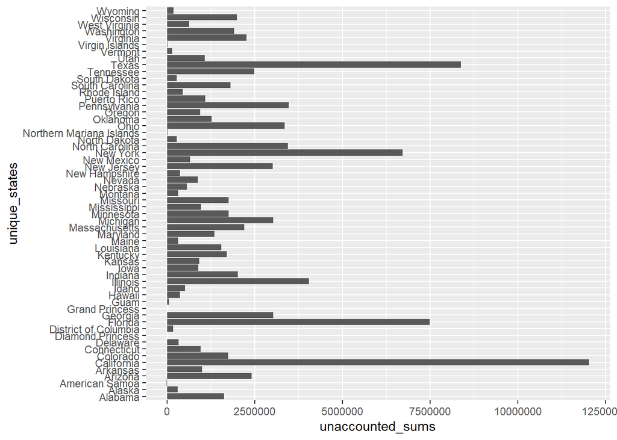

```r
# Recreating a dataframe to analyze
unaccounted_assessment <- data.frame(unique_states, unaccounted_sums)
# We can create a bar plot to evaluate the percentages of unaccounted cases in the US
ggplot(data = unaccounted_assessment) +
  geom_col(mapping = aes(x = unique_states, y = unaccounted_sums)) +
  coord_flip()
```